# ゲームハード週販レポート (2026.02.08)

国内ゲームハード週販レポート (2026-02-08)

- ハードウェアの販売データはファミ通の調査結果を基にしています。
- 一部のデータは処理上の都合により、週次値に調整しています｡
- 過去の週販レポート

## 直近4週間のハード売り上げ／累計推移

| 集計日 | ハード | 販売台数 | 累計台数 |
| --- | --- | --- | --- |
| 2026-01-18 | Nintendo Switch2 | 67,509 | 4,165,414 |
|  | Nintendo Switch | 27,234 | 36,489,755 |
|  | PlayStation5 | 9,983 | 7,354,946 |
|  | Xbox Series X\|S | 303 | 690,138 |
|  | PlayStation4 | 10 | 9,491,082 |
| 2026-01-25 | Nintendo Switch2 | 72,086 | 4,237,500 |
|  | Nintendo Switch | 17,515 | 36,507,270 |
|  | PlayStation5 | 9,766 | 7,364,712 |
|  | Xbox Series X\|S | 693 | 690,831 |
|  | PlayStation4 | 18 | 9,491,100 |
| 2026-02-01 | Nintendo Switch2 | 69,586 | 4,307,086 |
|  | PlayStation5 | 10,949 | 7,375,661 |
|  | Nintendo Switch | 10,678 | 36,517,948 |
|  | Xbox Series X\|S | 525 | 691,356 |
|  | PlayStation4 | 13 | 9,491,113 |
| 2026-02-08 | Nintendo Switch2 | 65,807 | 4,372,893 |
|  | PlayStation5 | 11,130 | 7,386,791 |
|  | Nintendo Switch | 8,892 | 36,526,840 |
|  | Xbox Series X\|S | 1,253 | 692,609 |
|  | PlayStation4 | 22 | 9,491,135 |

入手性が改善され､そこそこ普通に買えるようになったSwitch2は､先週から4千台ほど下がって6.5万台｡ 需要と供給のバランスを高水準で保っています｡

PS5は今週も1万台です｡こちらも安定しています｡

Switchの減少著しく､初めて1万台を割りました｡もちろん **歴代最低** の新記録です｡

Switch減少の大きな要因は「品切れ」と思われます｡ 通販サイトを見ても分かるのですが､Switchは在庫無し､予定の販売を終了したなど､買えない状態です｡ (中古品の供給が多いためプレ値はつきませんが) 今やSwitch2を買う方が､Switchを買うよりも簡単です｡

この品切れが季節的な一時的な現象なのか､今後も続く流れなのか､注視が必要です｡ Switch Liteが欲しいなら早めに買っておいた方が確実でしょうね｡

## 週販推移

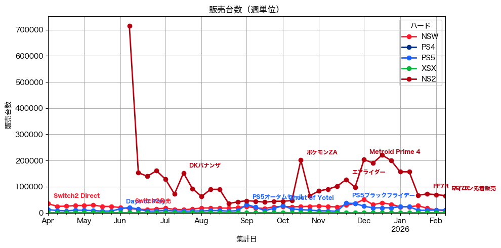

### 週販推移(拡大）

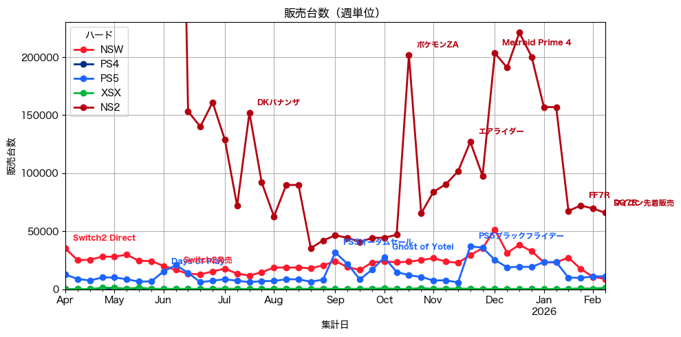

しばらくはNintendo Switch2が7万前後で､PS5が1万台前後で推移すると思われます｡ Switchについては､この先急減するのか､供給が復活して2万台程度に戻るのか､様子見です｡

## 前世代機の終息状況比較

次世代機の発売1ヶ月前からの1年間､前世代機の週販がどのように変化するかを比較しました｡

### 任天堂携帯機の終息状況

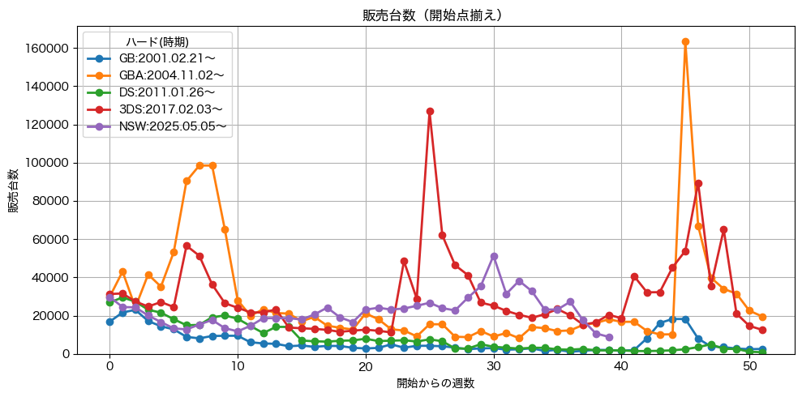

任天堂の旧世代携帯機の動きには2パターンあります｡

- 次世代機発売以降､急速に売上が低下し終息する｡GB､DSが該当します｡
- 次世代機発売以降も盛り上がるタイミングがあり､終息まで時間がかかる｡ GBA, 3DSが該当します｡

後者については任天堂が旧世代機にテコ入れを行っている影響が大きいです｡

- 2005/9/13(DS発売から10ヶ月後)にGAME BOY micro発売｡45週目近辺のオレンジ色のピークがこれです｡
- 2017/7/13(Switch発売から4ヶ月後)にNew2DSLL発売｡25週目近辺の赤色のピークはこれです｡

互換性がある順当進化の後継機の場合､任天堂は前世代機のテコ入れを行わず､ 急速に世代交代が進みます｡ 一方､革新的な変化があり､互換性がない場合には､任天堂は前世代機にテコ入れを行い､ 前世代機の延命を図ります｡

Nintendo Switch → Switch2の変化は前者なので､ 従来通りなら急速に売上が低下し終息するはずです｡ しかし､実際には(テコ入れがないためにピークはないものの) GBA､3DS終息時に匹敵する高い売上を維持し続けてきました｡ 前例に無い動きです｡ Switch2にLiteモデルがないことから､ Switch Liteが代替効かない機種として､GBA,3DSのパターンで推移しているのかも知れません｡

ただし､2026年2月に入ってから各店舗で在庫が切れるなど､ 供給減による急低下が始まっており､ここから終息に向かう可能性もあります｡

### 任天堂据え置き機の終息状況

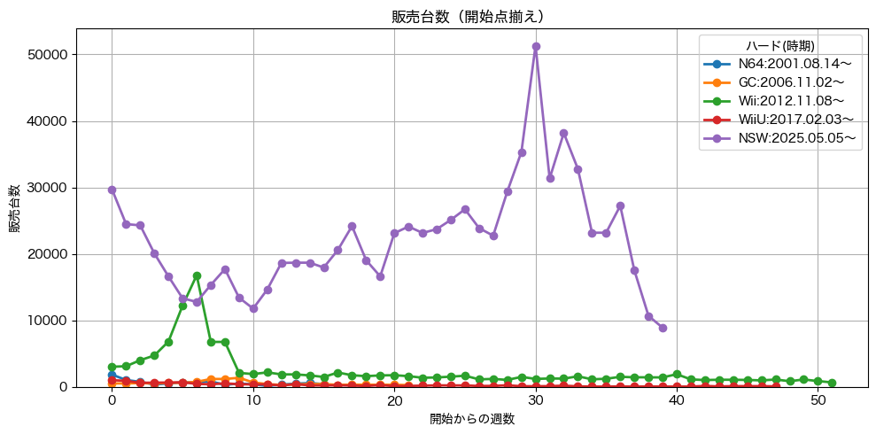

任天堂の据置機は次世代機になる頃には瀕死状態です｡ N64, GCは次世代機発売前から売れ行きが停止しており､次世代機発売後ももちろん動きはありません｡ Wiiは年末商戦で少し盛り上がるも､直後に底辺に落ち込み､その後回復することはありません｡

Switchの動きは「次世代機後の任天堂の据置機」としては初めてのケースです｡ やはりSwitchシリーズは『据置機』ではなく『携帯機』の売れ方をしていると考えた方がいいでしょう｡

### SONY据え置き機の終息状況

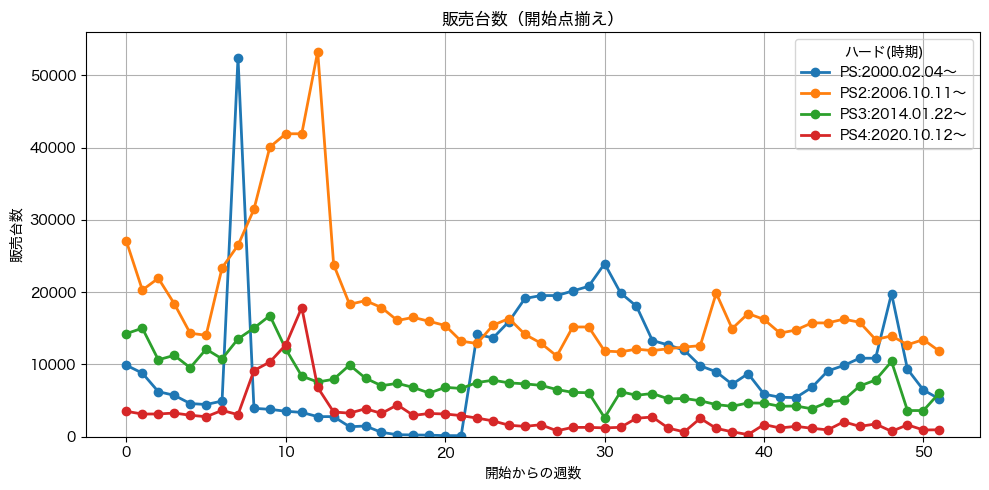

後継機発売後のPlayStationシリーズは､任天堂の据置機よりは断然に生き延びています｡

特異な動きをしているのは､青色のラインの初代PSです｡21周目から売上が盛り返しています｡ これは2000/7/7(PS2発売から4ヶ月後)にPS Oneが発売された影響です｡ 廉価版テコ入れにより旧機種が盛り上がるパターンです｡

こういった旧機種テコ入れはPS2, PS3, PS4には無く､ 徐々に売上が低下していく流れになります｡ただ明らかに PS2 > PS3 > PS4と､世代を経る毎に旧世代機の売上が下がる傾向があり､ 旧世代機が踏ん張れなくなっています｡

## 年末商戦後の推移比較

### SwitchとSwitch2:初年の年末商戦後の推移比較

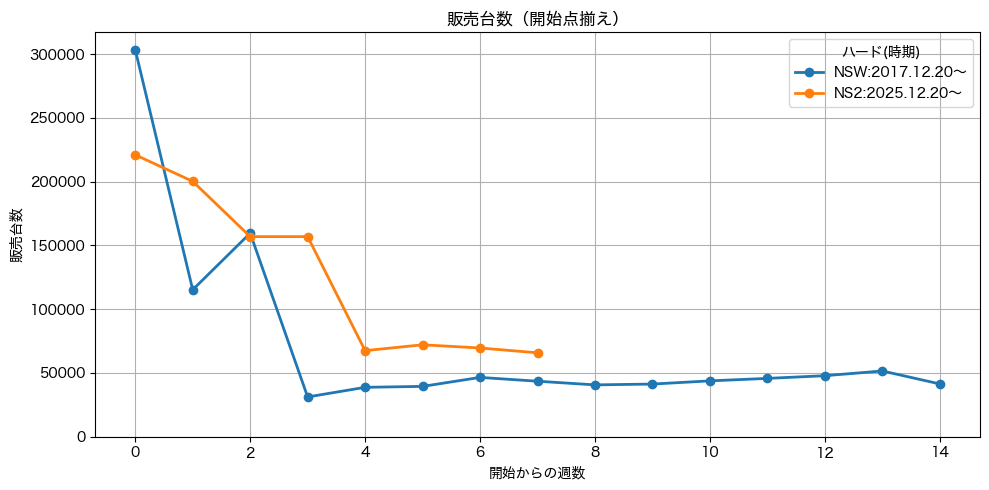

ホリデーシーズン商戦後のSwitch2とSwitchの推移比較です｡ Switchは5万台未満で推移するのに比べ､Switch2は7万台前後の推移が続いており､安定しています｡ Switch2の高い需要が続いています｡

### PS5の直近3年間の年末商戦後の推移比較

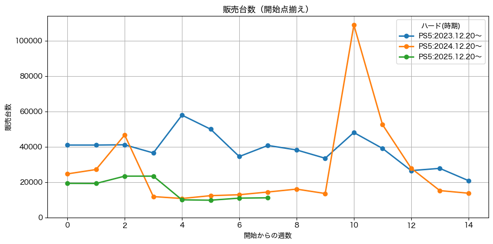

PS5DE日本語版の値下げ効果がホリデーシーズン後も継続しているか確認するために､ PS5の2023/12/20, 2024/12/20, 2025/12/20以降の週販のグラフを示します｡

2025年は12月中の年末商戦の段階で2023年､2024年を下回っています｡ ホリデー後も昨年を下回る水準が継続しており､値下げは販売台数を増加させる事は出来ていません｡ (先々週からコメントを書き換える部分がありません)

2025年はここからMHWs効果でブーストしたのですが､今年はそのようなブーストを期待できる要因はありません｡

## 月間販売推移

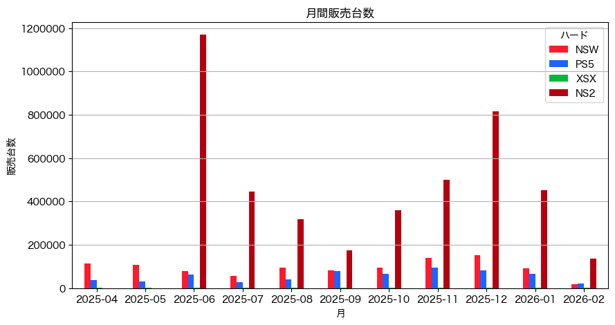

| year_month | NSW | PS5 | XSX | NS2 |
| --- | --- | --- | --- | --- |
| 2026-02 | 19,570 | 22,079 | 1,778 | 135,393 |

### Nintendo Switchの月間販売台数： 前々年､前年との比較

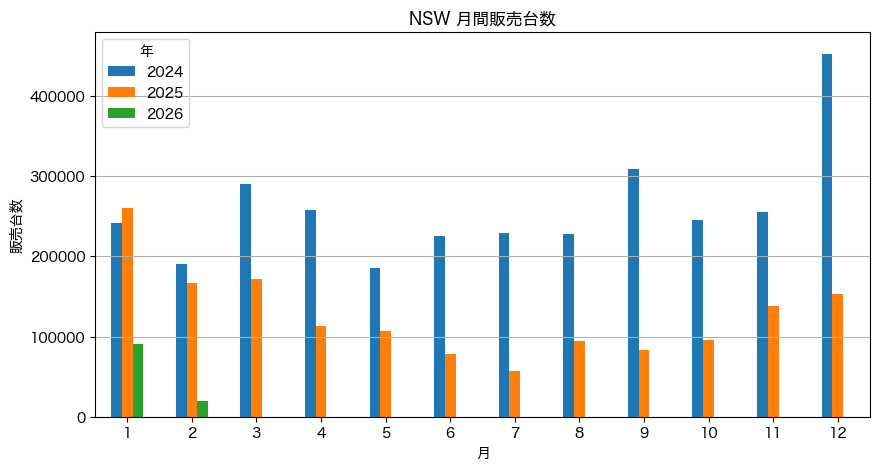

| 月 | 2025 | 2026 | YoY |
| --- | --- | --- | --- |
| 1 | 260,447 | 91,109 | 35.0% |
| 2 | 167,188 | 19,570 | 11.7% |
| 3 | 171,921 | 0 | 0.0% |
| 4 | 113,513 | 0 | 0.0% |
| 5 | 106,506 | 0 | 0.0% |
| 6 | 78,097 | 0 | 0.0% |
| 7 | 57,532 | 0 | 0.0% |
| 8 | 94,517 | 0 | 0.0% |
| 9 | 82,946 | 0 | 0.0% |
| 10 | 96,080 | 0 | 0.0% |
| 11 | 138,018 | 0 | 0.0% |
| 12 | 153,619 | 0 | 0.0% |

もしかすると､2月は前年比25%にも届かない可能性があります｡

### PlayStation 5の月間販売台数： 前々年､前年との比較

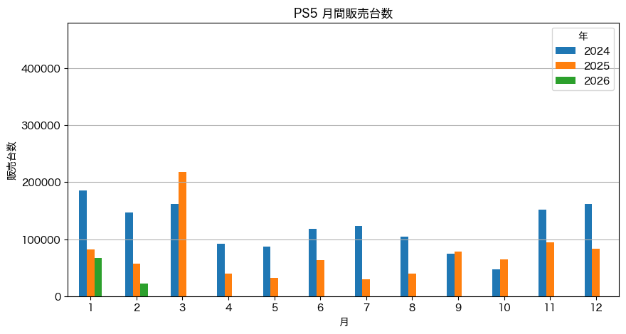

| 月 | 2025 | 2026 | YoY |
| --- | --- | --- | --- |
| 1 | 81,587 | 66,502 | 81.5% |
| 2 | 56,886 | 22,079 | 38.8% |
| 3 | 218,300 | 0 | 0.0% |
| 4 | 38,983 | 0 | 0.0% |
| 5 | 32,001 | 0 | 0.0% |
| 6 | 63,516 | 0 | 0.0% |
| 7 | 28,959 | 0 | 0.0% |
| 8 | 39,004 | 0 | 0.0% |
| 9 | 78,693 | 0 | 0.0% |
| 10 | 64,732 | 0 | 0.0% |
| 11 | 93,852 | 0 | 0.0% |
| 12 | 82,691 | 0 | 0.0% |

2月も半分を経過しました｡1月と同様に前年比80%程度(若干下回る)で落ち着きそうです｡ 急激な落ち込みは無いのですが､盛り上がりも無い状態です

## 累計販売推移

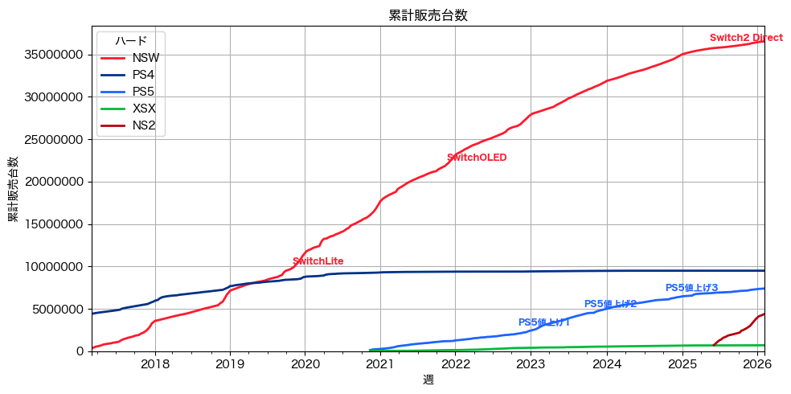

来週にはSwitch2の累計は440万台に達する見込みです｡ PS5の累計が来週740万台に達するのは困難なので､ 次回集計でSwitch2とPS5の累計差が300万台を切ると見込まれます｡

## Switch2初動状況

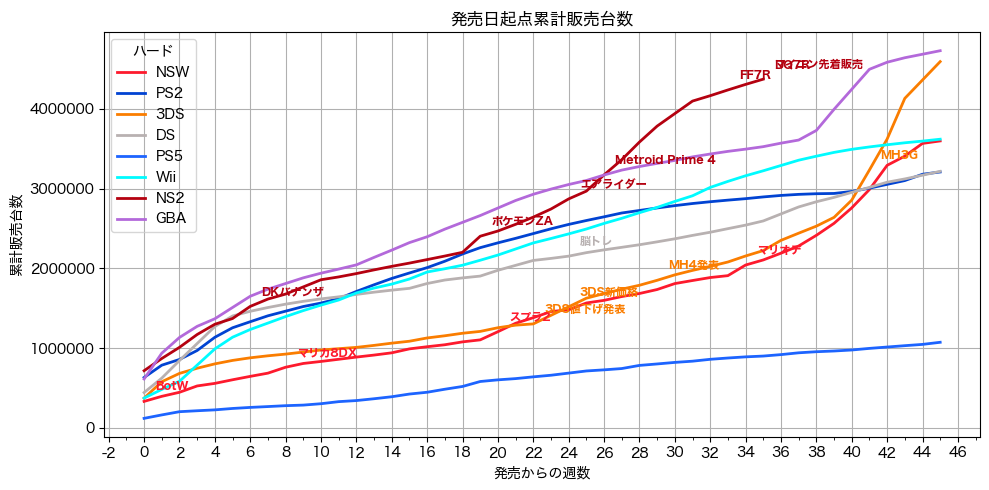

| ハード | 販売数 |
| --- | --- |
| NS2 | 4,372,893 |
| GBA | 3,526,221 |
| Wii | 3,223,673 |
| PS2 | 2,895,632 |
| DS | 2,594,400 |
| 3DS | 2,222,569 |
| NSW | 2,105,198 |
| PS5 | 899,448 |

Switch2の現状の推移ならGBAの40週近辺の年末商戦カーブを 上回って歴代1位を継続できそうです｡

## 年単位の状況

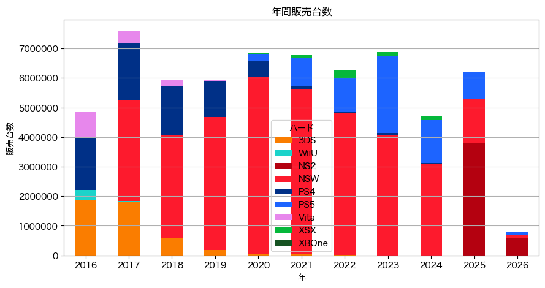

| year | 3DS | WiiU | NS2 | NSW | PS4 | PS5 | Vita | XSX | XBOne | 合計 |
| --- | --- | --- | --- | --- | --- | --- | --- | --- | --- | --- |
| 2016 | 1,874,457 | 336,151 | nan | nan | 1,790,883 | nan | 865,002 | nan | 8,897 | 4,875,390 |
| 2017 | 1,827,131 | 21,817 | nan | 3,407,158 | 1,935,247 | nan | 396,207 | nan | 14,664 | 7,602,224 |
| 2018 | 566,420 | nan | nan | 3,482,388 | 1,695,227 | nan | 181,728 | nan | 15,339 | 5,941,102 |
| 2019 | 191,173 | nan | nan | 4,493,903 | 1,196,153 | nan | 37,668 | nan | 8,315 | 5,927,212 |
| 2020 | 62,761 | nan | nan | 5,956,943 | 542,647 | 255,150 | nan | 31,424 | 3,585 | 6,852,510 |
| 2021 | 28,540 | nan | nan | 5,579,127 | 104,054 | 968,185 | nan | 97,234 | nan | 6,777,140 |
| 2022 | 10,664 | nan | nan | 4,804,546 | 22,823 | 1,154,054 | nan | 269,737 | nan | 6,261,824 |
| 2023 | 3,033 | nan | nan | 4,062,609 | 73,292 | 2,587,468 | nan | 141,712 | nan | 6,868,114 |
| 2024 | 162 | nan | nan | 3,109,103 | 13,728 | 1,454,149 | nan | 118,221 | nan | 4,695,363 |
| 2025 | nan | nan | 3,784,067 | 1,520,384 | 1,087 | 879,204 | nan | 31,226 | nan | 6,215,968 |
| 2026 | nan | nan | 588,826 | 110,679 | 88 | 88,581 | nan | 3,055 | nan | 791,229 |

PS4はいつまで集計するんでしょうかね｡

### 年単位のメーカーシェア

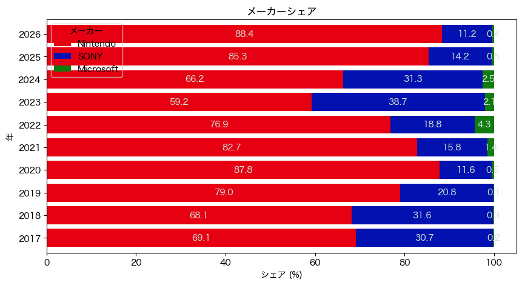

任天堂のシェアは88.7%から88.4%に減少しました｡ Switchの落ち込みの影響が出ています｡ 今後は85%~86%程度で落ち着くと思われます｡